## Activity Monitoring Report

#### Phase I–Loading and preprocessing the data.

Step 1: Load the data into R

```r
activity<-read.csv('./data/activity.csv', header=TRUE, na.strings='NA', stringsAsFactor=FALSE)
```

Step 2: Determine the number of dimensions in the dataset.

```r
dim(activity)
```

```
## [1] 17568     3
```

Step 3: Examine the structure of the dataset.

```r
str(activity)
```

```
## 'data.frame':    17568 obs. of  3 variables:
##  $ steps   : int  NA NA NA NA NA NA NA NA NA NA ...
##  $ date    : chr  "2012-10-01" "2012-10-01" "2012-10-01" "2012-10-01" ...
##  $ interval: int  0 5 10 15 20 25 30 35 40 45 ...
```

Step 4: Examine the head and tail of the dataset.

```r
head(activity, 20)
```

```
##    steps       date interval
## 1     NA 2012-10-01        0
## 2     NA 2012-10-01        5
## 3     NA 2012-10-01       10
## 4     NA 2012-10-01       15
## 5     NA 2012-10-01       20
## 6     NA 2012-10-01       25
## 7     NA 2012-10-01       30
## 8     NA 2012-10-01       35
## 9     NA 2012-10-01       40
## 10    NA 2012-10-01       45
## 11    NA 2012-10-01       50
## 12    NA 2012-10-01       55
## 13    NA 2012-10-01      100
## 14    NA 2012-10-01      105
## 15    NA 2012-10-01      110
## 16    NA 2012-10-01      115
## 17    NA 2012-10-01      120
## 18    NA 2012-10-01      125
## 19    NA 2012-10-01      130
## 20    NA 2012-10-01      135
```

```r
tail(activity, 20)
```

```
##       steps       date interval
## 17549    NA 2012-11-30     2220
## 17550    NA 2012-11-30     2225
## 17551    NA 2012-11-30     2230
## 17552    NA 2012-11-30     2235
## 17553    NA 2012-11-30     2240
## 17554    NA 2012-11-30     2245
## 17555    NA 2012-11-30     2250
## 17556    NA 2012-11-30     2255
## 17557    NA 2012-11-30     2300
## 17558    NA 2012-11-30     2305
## 17559    NA 2012-11-30     2310
## 17560    NA 2012-11-30     2315
## 17561    NA 2012-11-30     2320
## 17562    NA 2012-11-30     2325
## 17563    NA 2012-11-30     2330
## 17564    NA 2012-11-30     2335
## 17565    NA 2012-11-30     2340
## 17566    NA 2012-11-30     2345
## 17567    NA 2012-11-30     2350
## 17568    NA 2012-11-30     2355
```

Step 5: Transform the ‘date’ variable to date mode

```r
activity<-transform(activity,
                    date = as.Date(date, format='%Y-%m-%d')
                    )
```

Step 6: Summarize each variable in the dataset.

```r
summary(activity)
```

```
##      steps             date               interval
##  Min.   :  0.00   Min.   :2012-10-01   Min.   :   0.0
##  1st Qu.:  0.00   1st Qu.:2012-10-16   1st Qu.: 588.8
##  Median :  0.00   Median :2012-10-31   Median :1177.5
##  Mean   : 37.38   Mean   :2012-10-31   Mean   :1177.5
##  3rd Qu.: 12.00   3rd Qu.:2012-11-15   3rd Qu.:1766.2
##  Max.   :806.00   Max.   :2012-11-30   Max.   :2355.0
##  NA's   :2304
```

Step 7: Review the names of each variable.

```r
names(activity)
```

```
## [1] "steps"    "date"     "interval"
```

Analysis Phase: What is the mean number of steps taken per day?

```r
library(sqldf)
avg_num_steps_per_day<-sqldf('SELECT date, avg(steps) as avg_steps FROM activity
                             GROUP BY
                             Date
                             ORDER BY
                             date;')
avg_num_steps_per_day
```

```
##          date         avg_steps
## 1  2012-10-01              <NA>
## 2  2012-10-02            0.4375
## 3  2012-10-03  39.4166666666667
## 4  2012-10-04  42.0694444444444
## 5  2012-10-05  46.1597222222222
## 6  2012-10-06  53.5416666666667
## 7  2012-10-07  38.2465277777778
## 8  2012-10-08              <NA>
## 9  2012-10-09  44.4826388888889
## 10 2012-10-10            34.375
## 11 2012-10-11  35.7777777777778
## 12 2012-10-12  60.3541666666667
## 13 2012-10-13  43.1458333333333
## 14 2012-10-14  52.4236111111111
```

[output cut: 47 more lines]

```r
with(activity, aggregate(steps, by=list(date=date), FUN=mean))
```

```
##          date          x
## 1  2012-10-01         NA
## 2  2012-10-02  0.4375000
## 3  2012-10-03 39.4166667
## 4  2012-10-04 42.0694444
## 5  2012-10-05 46.1597222
## 6  2012-10-06 53.5416667
## 7  2012-10-07 38.2465278
## 8  2012-10-08         NA
## 9  2012-10-09 44.4826389
## 10 2012-10-10 34.3750000
## 11 2012-10-11 35.7777778
## 12 2012-10-12 60.3541667
## 13 2012-10-13 43.1458333
## 14 2012-10-14 52.4236111
```

[output cut: 47 more lines]

If you do not understand the difference between a histogram and a barplot, research the difference between them. Make a histogram of the total number of steps taken each day

```r
total_steps_per_day<-sqldf('SELECT date, sum(steps) as daily_total_steps FROM activity
                          GROUP BY
                          date
                          ORDER BY
                          date;')
str(total_steps_per_day)
```

```
## 'data.frame':    61 obs. of  2 variables:
##  $ date             : Date, format: "2012-10-01" "2012-10-02" ...
##  $ daily_total_steps: chr  NA "126" "11352" "12116" ...
```

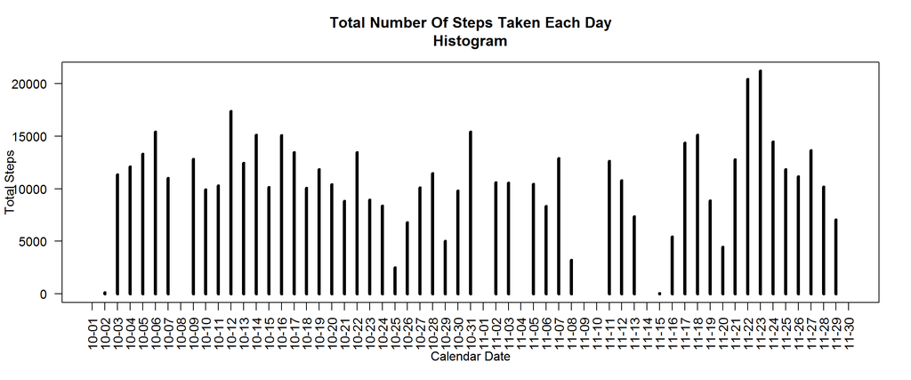

```r
total_steps_per_day<-transform(total_steps_per_day,
                               daily_total_steps = as.numeric(daily_total_steps)
                               )

min.step_day<-min(total_steps_per_day$daily_total_steps, na.rm=TRUE)

max.step_day<-max(total_steps_per_day$daily_total_steps, na.rm=TRUE)



with(total_steps_per_day, plot(daily_total_steps ~ date,
                               type = 'h',
                               lwd = 4,
                               axes=FALSE,
                               ylab = 'Total Steps',
                               xlab = 'Calendar Date',
                               main = 'Total Number Of Steps Taken Each Day\nHistogram'
                               )
     )
box()
axis(1, total_steps_per_day$date, format(total_steps_per_day$date, format='%m-%d'), las=2 )
axis(2, ylim=c(0, max.step_day), las =1)
```

Calculate and report the mean and median of the total number of steps taken per day

```r
mean_steps_day<-round(mean(total_steps_per_day$daily_total_steps, na.rm=TRUE), 2)
mean_steps_day<-as.character(mean_steps_day)
```

The mean number of steps taken per day is 10766.19

```r
median_steps_day<-median(total_steps_per_day$daily_total_steps, na.rm=TRUE)
steps_day_median<-as.character(median_steps_day)
```

The median number of steps taken per day is 10765

What is the average daily activity pattern? Make a time series plot (i.e. type = “l”) of the 5-minute interval (x-axis) and the average number of steps taken, averaged across all days (y-axis)

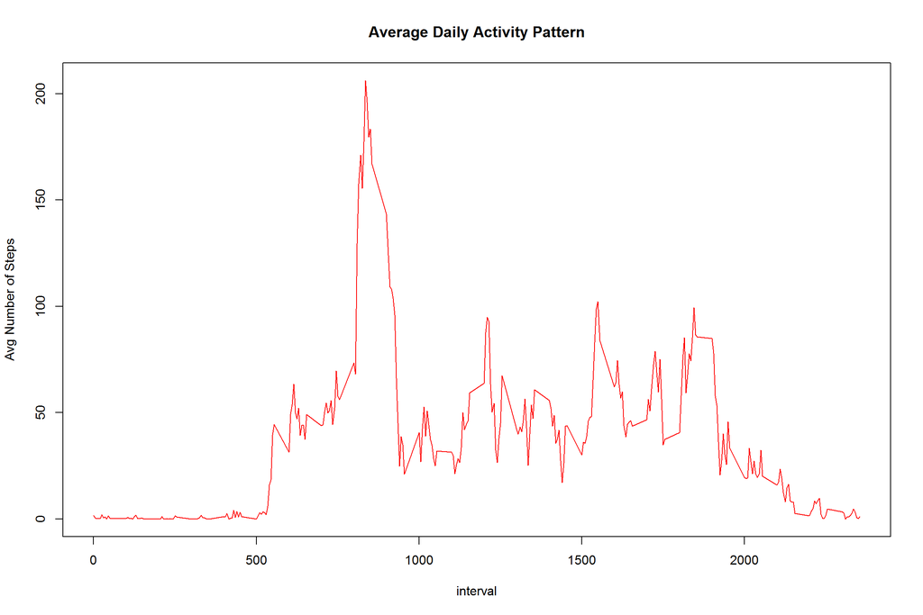

```r
interval_avg_steps<-sqldf('SELECT interval, avg(steps) as avg_steps_by_interval FROM activity
                        GROUP by
                        interval
                        ORDER BY
                        interval;')

with(interval_avg_steps, plot(avg_steps_by_interval ~ interval,
                              type = 'l',
                              col = 'red',
                              ylab ='Avg Number of Steps',
                              main = 'Average Daily Activity Pattern'
                              )
     )
```

```r
avg_num_steps_per_day<-na.omit(avg_num_steps_per_day)

avg_num_steps_per_day<-transform(avg_num_steps_per_day,
                                 avg_steps = as.numeric(avg_steps)
                                 )

max_steps_per_day<-max(avg_num_steps_per_day$avg_steps)

max_steps_per_day
```

```
## [1] 73.59028
```

```r
which_date<-avg_num_steps_per_day[which(avg_num_steps_per_day$avg_steps==max_steps_per_day), 1]
```

Calculate and report the total number of missing values in the dataset (i.e. the total number of rows with NAs)

```r
na.activity<-activity[!complete.cases(activity),]
total_number_missing_values<-nrow(na.activity)
```

The total number of missing values in the dataset is 2304

Devise a strategy for filling in all of the missing values in the dataset. The strategy does not need to be sophisticated. For example, you could use the mean/median for that day, or the mean for that 5-minute interval, etc.

```r
activity_fill<-sqldf("SELECT A.date, A.interval, A.steps, I.avg_steps_by_interval FROM activity as A
                       LEFT OUTER JOIN
                               interval_avg_steps AS I
                                        ON
                                         A.interval = I.interval ;")

str(activity_fill)
```

```
## 'data.frame':    17568 obs. of  4 variables:
##  $ date                 : Date, format: "2012-10-01" "2012-10-01" ...
##  $ interval             : int  0 5 10 15 20 25 30 35 40 45 ...
##  $ steps                : int  NA NA NA NA NA NA NA NA NA NA ...
##  $ avg_steps_by_interval: num  1.717 0.3396 0.1321 0.1509 0.0755 ...
```

```r
activity_fill<-transform(activity_fill,
                         steps = as.numeric(steps)
                         )

str(activity_fill)
```

```
## 'data.frame':    17568 obs. of  4 variables:
##  $ date                 : Date, format: "2012-10-01" "2012-10-01" ...
##  $ interval             : int  0 5 10 15 20 25 30 35 40 45 ...
##  $ steps                : num  NA NA NA NA NA NA NA NA NA NA ...
##  $ avg_steps_by_interval: num  1.717 0.3396 0.1321 0.1509 0.0755 ...
```

```r
num_records<-nrow(activity_fill)
num_records
```

```
## [1] 17568
```

```r
for(i in 1:num_records){
        if( is.na(activity_fill$steps[i])==TRUE){
              activity_fill$steps[i]<-activity_fill$avg_steps_by_interval[i]
      }

}

activity_fill<-activity_fill[,1:3]

head(activity_fill, 10)
```

```
##          date interval     steps
## 1  2012-10-01        0 1.7169811
## 2  2012-10-01        5 0.3396226
## 3  2012-10-01       10 0.1320755
## 4  2012-10-01       15 0.1509434
## 5  2012-10-01       20 0.0754717
## 6  2012-10-01       25 2.0943396
## 7  2012-10-01       30 0.5283019
## 8  2012-10-01       35 0.8679245
## 9  2012-10-01       40 0.0000000
## 10 2012-10-01       45 1.4716981
```

```r
summary(activity_fill$steps)
```

```
##    Min. 1st Qu.  Median    Mean 3rd Qu.    Max.
##    0.00    0.00    0.00   37.38   27.00  806.00
```

```r
activity_agg<-sqldf('SELECT date, sum(steps) as total_steps FROM activity_fill
                        GROUP BY date
                        ORDER BY date;')
```

Make a histogram of the total number of steps taken each day.

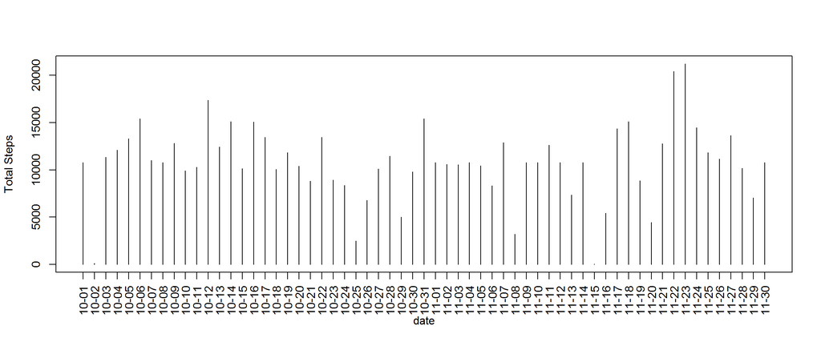

```r
with(activity_agg, plot(total_steps ~ date,
                                type = 'h',
                                axes = FALSE,
                                ylab = 'Total Steps')
     )
box()
axis(1, activity_agg$date, format(activity_agg$date, '%m-%d'), las=2)
axis(2, ylim=c(0, max(activity_agg$steps)))
```

Calculate and report the mean and median total number of steps taken per day

```r
activity_fill_mean<-mean(activity_agg$total_steps)

activity_fill_mean<-as.character(round((activity_fill_mean),2))

activity_fill_median<-median(activity_agg$total_steps)

activity_fill_median<-as.character(round((activity_fill_median),2))
```

The new mean is 10766.19

The new median is 10766.19

Do these values differ from the estimates from the first part of the assignment?

```r
activity_fill_mean<-as.numeric(activity_fill_mean)

mean_steps_day<-as.numeric(mean_steps_day)

activity_mean_delta<-(activity_fill_mean - mean_steps_day)/mean_steps_day

activity_mean_delta
```

```
## [1] 0
```

```r
activity_fill_median<-as.numeric(activity_fill_median)

steps_day_median<-as.numeric(steps_day_median)

activity_media_delta<-(activity_fill_median - steps_day_median)/steps_day_median

activity_media_delta
```

```
## [1] 0.0001105434
```

What is the impact of imputing missing data on the estimates of the total daily number of steps?

```r
summary(activity_fill$steps)
```

```
##    Min. 1st Qu.  Median    Mean 3rd Qu.    Max.
##    0.00    0.00    0.00   37.38   27.00  806.00
```

```r
summary(activity$steps)
```

```
##    Min. 1st Qu.  Median    Mean 3rd Qu.    Max.    NA's
##    0.00    0.00    0.00   37.38   12.00  806.00    2304
```

```r
activity_fill$weekpart<-NA

num_rec<-nrow(activity_fill)

for(i in 1:num_rec){
        if(weekdays(activity_fill$date[i])=='Saturday'){
                activity_fill$weekpart[i]<-'weekend'
        } else if (weekdays(activity_fill$date[i])=='Sunday'){
                activity_fill$weekpart[i]<-'weekend'
        } else {
              activity_fill$weekpart[i]<-'weekday'
        }
}


head(activity_fill, 100)
```

```
##           date interval       steps weekpart
## 1   2012-10-01        0   1.7169811  weekday
## 2   2012-10-01        5   0.3396226  weekday
## 3   2012-10-01       10   0.1320755  weekday
## 4   2012-10-01       15   0.1509434  weekday
## 5   2012-10-01       20   0.0754717  weekday
## 6   2012-10-01       25   2.0943396  weekday
## 7   2012-10-01       30   0.5283019  weekday
## 8   2012-10-01       35   0.8679245  weekday
## 9   2012-10-01       40   0.0000000  weekday
## 10  2012-10-01       45   1.4716981  weekday
## 11  2012-10-01       50   0.3018868  weekday
## 12  2012-10-01       55   0.1320755  weekday
## 13  2012-10-01      100   0.3207547  weekday
## 14  2012-10-01      105   0.6792453  weekday
```

[output cut: 86 more lines]

```r
activity_fill<-transform(activity_fill,
                         weekpart=factor(weekpart)
                         )


summary(activity_fill$weekpart)
```

```
## weekday weekend
##   12960    4608
```

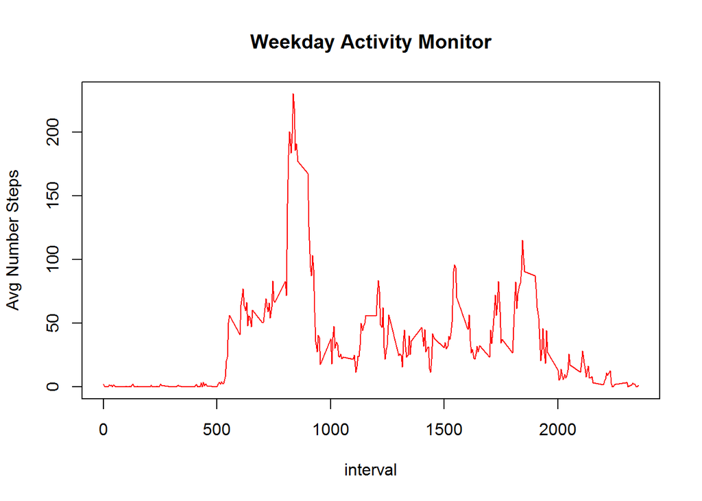

```r
weekdays_subset<-sqldf("SELECT interval, avg(steps) as avg_steps FROM activity_fill
                       WHERE
                        weekpart='weekday'
                       GROUP BY
                        interval;")

with(weekdays_subset, plot(avg_steps ~ interval,
                           type = 'l',
                           col = 'red',
                           ylab = 'Avg Number Steps',
                           main = 'Weekday Activity Monitor'
                           )
     )
```

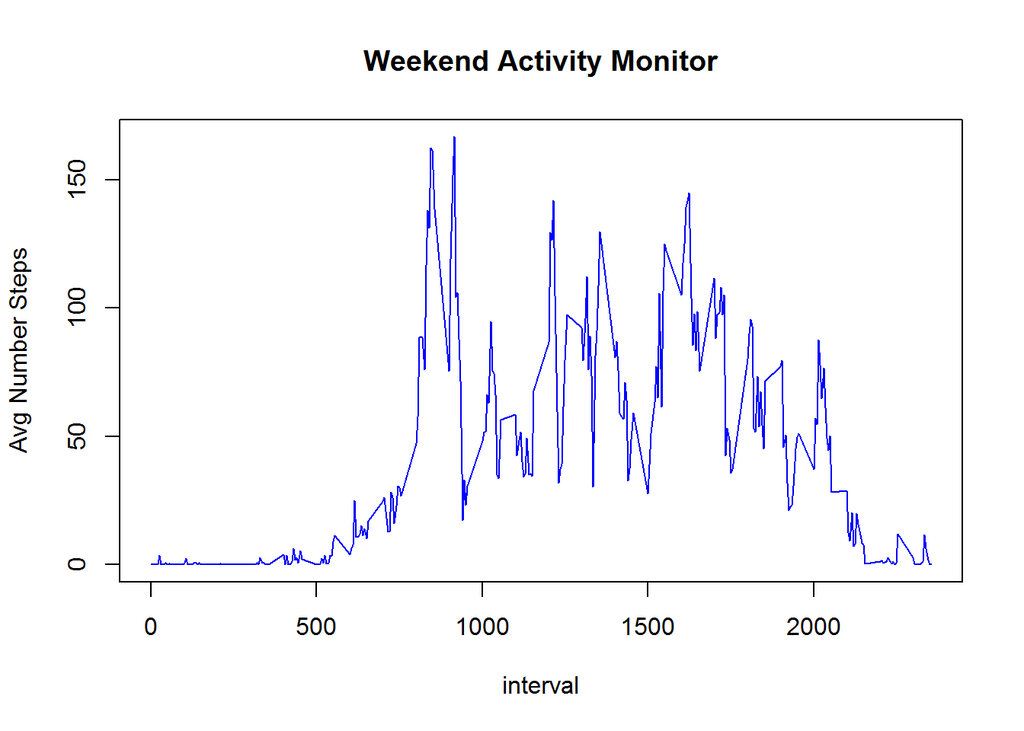

```r
weekend_subset<-sqldf("SELECT interval, avg(steps) as avg_steps FROM activity_fill
                       WHERE
                        weekpart='weekend'
                       GROUP BY
                        interval;")


with(weekend_subset, plot(avg_steps ~ interval,
                           type = 'l',
                           col = 'blue',
                           ylab = 'Avg Number Steps',
                           main = 'Weekend Activity Monitor'
                           )
     )
```